# Regression Analysis of Global Video Game Sales

Edouard Atanesyan

5/9/2026

## The Problem

The global video game industry generates hundreds of billions of dollars in annual revenue, yet many titles fail to recoup their development costs. A **game publisher or studio executive** needs to understand which factors drive global sales in order to make smarter decisions about which genres to invest in, which consoles to target, and how critic reception translates into commercial performance.

This analysis uses multiple linear regression to predict global video game sales using critic score, genre, and console. The dataset is the *Video Game Sales 2024* dataset from VGChartz, available on Kaggle (https://www.kaggle.com/datasets/asaniczka/video-game-sales-2024). It covers over 64,000 commercial releases from 1971 to 2024.

## Descriptive Analysis

### Missing Values

The raw dataset contained 64,016 observations. Of the key variables used in this analysis, **total_sales** had 45,094 missing values and **critic_score** had 57,338 missing values. **genre** and **console** had 0 missing values. Because **critic_score** is central to our research question, we removed all rows missing either sales or critic score, and dropped 148 titles with zero recorded sales because the log of zero is undefined. The working dataset contains 3,978 observations.

This filtering matters for interpretation. Critic scores are mostly recorded for prominent releases, so the sample over-represents well-known games, and the results describe that population rather than every game ever released.

### Distribution of the Dependent Variable

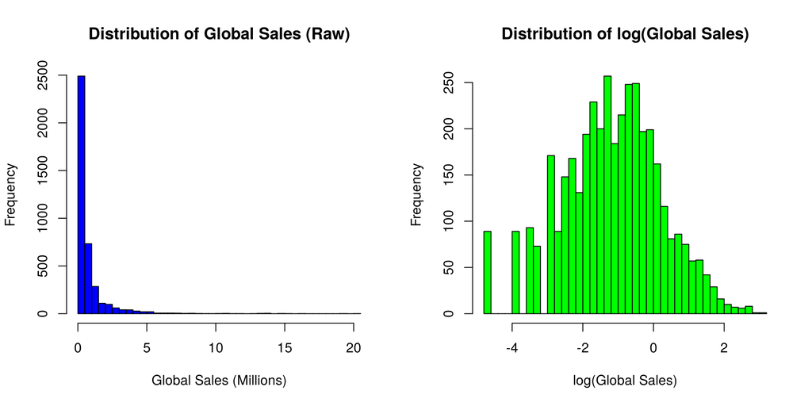

Raw global sales are heavily right-skewed: a small number of blockbusters sell tens of millions of units while most titles sell well under one million. After the log transformation the distribution is approximately symmetric.

Linear regression does not require the dependent variable itself to be normally distributed. The normality assumption applies to the **error terms**, which we check through the residuals of the fitted model below. We use the log transformation for two other reasons: it keeps a handful of extreme blockbusters from dominating the fit, and it lets us read coefficients as percentage changes in sales, which is a natural scale for a business decision.

### Relationships Among Variables

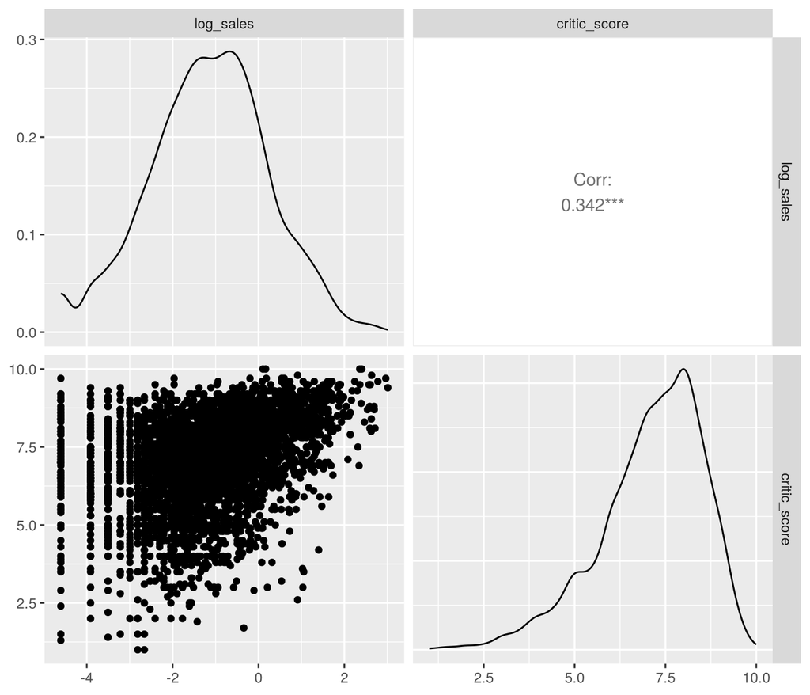

Critic score has a positive correlation with log(Global Sales), suggesting higher-reviewed games tend to sell more.

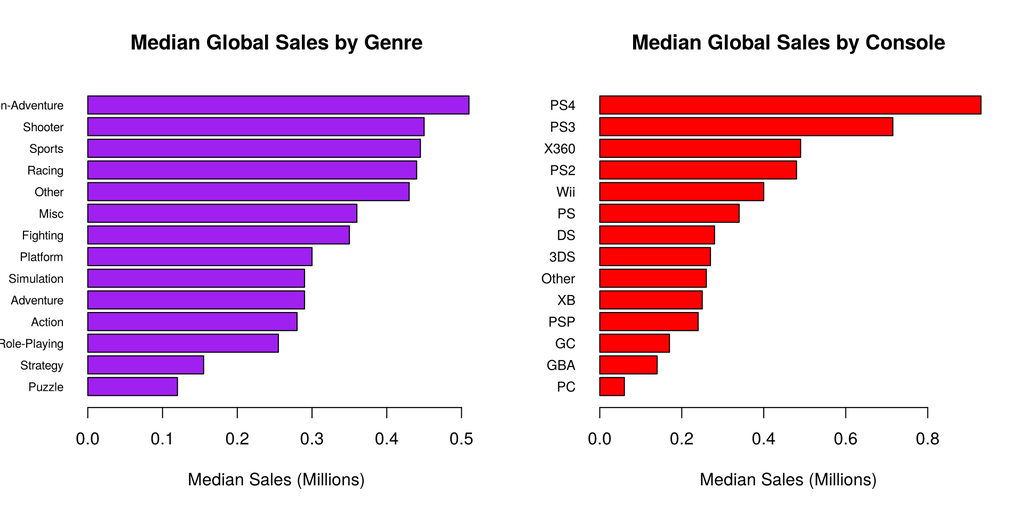

Median sales vary meaningfully across both genre and console, suggesting both will be useful predictors in the regression model.

### Simplifying the Categorical Variables

In the filtered sample, console has 27 levels and genre has 20, and several levels contain only a handful of games (some have a single title). Coefficients estimated from so few observations are unstable and hard to interpret. We therefore combined:

- **Consoles** with fewer than 100 titles into an “Other” category (DC, GB, GBC, GEN, N64, NES, NS, PSN, PSV, SAT, SNES, WiiU, XBL, XOne), leaving 14 console groups. The Xbox 360, the most common console in the sample, is the reference group.
- **Genres** with fewer than 50 titles into an “Other” category (Board Game, Education, MMO, Music, Party, Sandbox, Visual Novel), leaving 14 genre groups. Action, the most common genre, is the reference group.

The trade-off is that “Other” console mixes very different platforms (for example retro systems and the Switch), so its coefficient should not be read as describing any single console.

## Model Building and Selection

We fit five models using log(total_sales) as the response variable and selected the final model based on partial F-tests, adjusted R², AIC, BIC, and diagnostic plots.

- **Model 1**: Numeric predictor only, **critic_score**
- **Model 2**: Adding categorical predictors with all original levels, **genre** and **console**
- **Model 3**: Model 2 with the simplified genre and console groups
- **Model 4**: Model 3 with **log(critic_score)** to test a non-linear relationship
- **Model 5 (Final)**: Model 3 plus a **critic_score × console** interaction

### Model 1: Numeric Predictor Only

```
##
## Call:
## lm(formula = log_sales ~ critic_score, data = vg)
##
## Residuals:
##     Min      1Q  Median      3Q     Max
## -4.2932 -0.7922  0.0983  0.8861  3.5818
##
## Coefficients:
##              Estimate Std. Error t value Pr(>|t|)
## (Intercept)  -3.52360    0.10464  -33.67   <2e-16 ***
## critic_score  0.33109    0.01444   22.93   <2e-16 ***
## ---
## Signif. codes:  0 '***' 0.001 '**' 0.01 '*' 0.05 '.' 0.1 ' ' 1
##
## Residual standard error: 1.304 on 3976 degrees of freedom
## Multiple R-squared:  0.1168, Adjusted R-squared:  0.1166
## F-statistic: 525.9 on 1 and 3976 DF,  p-value: < 2.2e-16
```

### Model 2: Adding Categorical Predictors (All Levels)

```
##
## Call:
## lm(formula = log_sales ~ critic_score + genre + console, data = vg)
##
## Residuals:
##     Min      1Q  Median      3Q     Max
## -4.9749 -0.7120 -0.0047  0.7439  4.3790
##
## Coefficients:
##                       Estimate Std. Error t value Pr(>|t|)
## (Intercept)           -3.59329    0.13711 -26.207  < 2e-16 ***
## critic_score           0.33931    0.01321  25.689  < 2e-16 ***
## genreAction-Adventure -0.07278    0.14322  -0.508 0.611354
## genreAdventure        -0.03266    0.08882  -0.368 0.713113
## genreBoard Game        1.38023    1.14214   1.208 0.226945
## genreEducation        -0.82456    0.80508  -1.024 0.305808
## genreFighting         -0.04826    0.08950  -0.539 0.589764
## genreMMO              -0.49949    0.56994  -0.876 0.380873
## genreMisc              0.07606    0.08755   0.869 0.384996
## genreMusic            -0.03350    0.28942  -0.116 0.907866
## genreParty             0.24315    0.41214   0.590 0.555248
## genrePlatform          0.07332    0.07946   0.923 0.356218
## genrePuzzle           -0.66004    0.11956  -5.521 3.60e-08 ***
## genreRacing            0.02674    0.07637   0.350 0.726204
## genreRole-Playing     -0.33496    0.07014  -4.775 1.86e-06 ***
## genreSandbox           1.89746    1.14228   1.661 0.096771 .
## genreShooter           0.13529    0.06724   2.012 0.044294 *
## genreSimulation        0.17070    0.10473   1.630 0.103207
## genreSports            0.03248    0.06649   0.489 0.625212
## genreStrategy         -0.45768    0.10438  -4.385 1.19e-05 ***
## genreVisual Novel     -2.96708    1.13998  -2.603 0.009283 **
## consoleDC             -0.86086    0.22896  -3.760 0.000172 ***
## consoleDS              0.07303    0.12397   0.589 0.555825
## consoleGB              0.88680    0.57660   1.538 0.124134
## consoleGBA            -0.71028    0.12155  -5.844 5.52e-09 ***
## consoleGBC             1.08983    0.81254   1.341 0.179911
## consoleGC             -0.55905    0.12086  -4.625 3.86e-06 ***
## consoleGEN            -0.66357    1.14293  -0.581 0.561550
## consoleN64            -0.07590    0.16981  -0.447 0.654914
## consoleNES             2.94595    1.14040   2.583 0.009823 **
```

[output cut: 8 more lines]

```
## consolePSV             0.20805    0.34351   0.606 0.544770
## consoleSAT            -0.59694    0.34459  -1.732 0.083293 .
## consoleSNES           -0.37730    0.80966  -0.466 0.641241
## consoleWii             0.36975    0.12140   3.046 0.002336 **
## consoleWiiU           -0.15680    0.18683  -0.839 0.401374
## consoleX360            0.51449    0.11168   4.607 4.22e-06 ***
## consoleXB             -0.30354    0.14991  -2.025 0.042950 *
## consoleXBL            -3.63711    0.80979  -4.491 7.28e-06 ***
## consoleXOne            0.55752    0.17566   3.174 0.001516 **
## ---
## Signif. codes:  0 '***' 0.001 '**' 0.01 '*' 0.05 '.' 0.1 ' ' 1
##
## Residual standard error: 1.134 on 3931 degrees of freedom
## Multiple R-squared:  0.3397, Adjusted R-squared:  0.3319
## F-statistic: 43.96 on 46 and 3931 DF,  p-value: < 2.2e-16
```

### Model 3: Simplified Categorical Predictors

```
##
## Call:
## lm(formula = log_sales ~ critic_score + genre_grp + console_grp,
##     data = vg)
##
## Residuals:
##     Min      1Q  Median      3Q     Max
## -4.9529 -0.7195 -0.0112  0.7461  4.3823
##
## Coefficients:
##                           Estimate Std. Error t value Pr(>|t|)
## (Intercept)               -3.06869    0.10830 -28.334  < 2e-16 ***
## critic_score               0.33698    0.01325  25.428  < 2e-16 ***
## genre_grpAction-Adventure -0.01773    0.14282  -0.124 0.901224
## genre_grpAdventure        -0.03197    0.08934  -0.358 0.720478
## genre_grpFighting         -0.09790    0.08969  -1.092 0.275087
## genre_grpMisc              0.08023    0.08843   0.907 0.364319
## genre_grpPlatform          0.05308    0.08014   0.662 0.507834
## genre_grpPuzzle           -0.66950    0.12083  -5.541 3.21e-08 ***
## genre_grpRacing            0.04892    0.07706   0.635 0.525585
## genre_grpRole-Playing     -0.34502    0.07083  -4.871 1.15e-06 ***
## genre_grpShooter           0.15394    0.06790   2.267 0.023439 *
## genre_grpSimulation        0.16475    0.10587   1.556 0.119754
## genre_grpSports            0.05458    0.06710   0.813 0.416035
## genre_grpStrategy         -0.46044    0.10521  -4.376 1.24e-05 ***
## genre_grpOther            -0.10225    0.20596  -0.496 0.619605
## console_grp3DS            -0.52968    0.11234  -4.715 2.50e-06 ***
## console_grpDS             -0.43298    0.08978  -4.823 1.47e-06 ***
## console_grpGBA            -1.21867    0.08516 -14.310  < 2e-16 ***
## console_grpGC             -1.06908    0.08303 -12.876  < 2e-16 ***
## console_grpPC             -1.83107    0.08611 -21.265  < 2e-16 ***
## console_grpPS             -0.24579    0.09422  -2.609 0.009127 **
## console_grpPS2            -0.03796    0.08249  -0.460 0.645437
## console_grpPS3             0.23820    0.07142   3.335 0.000861 ***
## console_grpPS4             0.38363    0.12643   3.034 0.002426 **
## console_grpPSP            -0.54451    0.07669  -7.100 1.47e-12 ***
## console_grpWii            -0.14175    0.08415  -1.685 0.092159 .
## console_grpXB             -0.81160    0.12189  -6.658 3.15e-11 ***
## console_grpOther          -0.72097    0.07945  -9.075  < 2e-16 ***
## ---
## Signif. codes:  0 '***' 0.001 '**' 0.01 '*' 0.05 '.' 0.1 ' ' 1
##
## Residual standard error: 1.147 on 3950 degrees of freedom
## Multiple R-squared:  0.3216, Adjusted R-squared:  0.317
## F-statistic: 69.36 on 27 and 3950 DF,  p-value: < 2.2e-16
```

Model 3 uses 28 coefficients instead of 47 and has a lower BIC than Model 2 (1.25922^{4} vs 1.26425^{4}), at a small cost in adjusted R² (0.317 vs 0.332). The simpler grouping keeps nearly all of the explanatory power while making each coefficient easier to read.

### Testing Genre and Console

```
## Analysis of Variance Table
##
## Model 1: log_sales ~ critic_score
## Model 2: log_sales ~ critic_score + genre_grp + console_grp
##   Res.Df    RSS Df Sum of Sq      F    Pr(>F)
## 1   3976 6765.0
## 2   3950 5196.2 26    1568.8 45.867 < 2.2e-16 ***
## ---
## Signif. codes:  0 '***' 0.001 '**' 0.01 '*' 0.05 '.' 0.1 ' ' 1
```

The partial F-test comparing Model 1 to Model 3 has a p-value well below 0.05. This tells us that **genre and console together** significantly improve model fit. On its own, this joint test does not tell us whether each variable is significant separately.

To test each variable separately, we drop one categorical variable at a time from Model 3 and compare with a partial F-test.

```
## Analysis of Variance Table
##
## Model 1: log_sales ~ critic_score + console_grp
## Model 2: log_sales ~ critic_score + genre_grp + console_grp
##   Res.Df    RSS Df Sum of Sq      F    Pr(>F)
## 1   3963 5340.2
## 2   3950 5196.2 13    144.01 8.4212 < 2.2e-16 ***
## ---
## Signif. codes:  0 '***' 0.001 '**' 0.01 '*' 0.05 '.' 0.1 ' ' 1
```

```
## Analysis of Variance Table
##
## Model 1: log_sales ~ critic_score + genre_grp
## Model 2: log_sales ~ critic_score + genre_grp + console_grp
##   Res.Df    RSS Df Sum of Sq      F    Pr(>F)
## 1   3963 6488.4
## 2   3950 5196.2 13    1292.2 75.559 < 2.2e-16 ***
## ---
## Signif. codes:  0 '***' 0.001 '**' 0.01 '*' 0.05 '.' 0.1 ' ' 1
```

Both p-values are well below 0.05. Genre is significant as a group after controlling for critic score and console, and console is significant as a group after controlling for critic score and genre.

### Model 4: log(critic_score), Tested but Not Selected

```
##
## Call:
## lm(formula = log_sales ~ log(critic_score) + genre_grp + console_grp,
##     data = vg)
##
## Residuals:
##     Min      1Q  Median      3Q     Max
## -4.8398 -0.7481 -0.0105  0.7571  4.2185
##
## Coefficients:
##                           Estimate Std. Error t value Pr(>|t|)
## (Intercept)               -4.19082    0.15942 -26.288  < 2e-16 ***
## log(critic_score)          1.80866    0.07828  23.105  < 2e-16 ***
## genre_grpAction-Adventure -0.01148    0.14463  -0.079 0.936714
## genre_grpAdventure        -0.02999    0.09047  -0.332 0.740274
## genre_grpFighting         -0.07909    0.09080  -0.871 0.383788
## genre_grpMisc              0.09251    0.08952   1.033 0.301511
## genre_grpPlatform          0.04599    0.08117   0.567 0.570993
## genre_grpPuzzle           -0.66129    0.12237  -5.404 6.89e-08 ***
## genre_grpRacing            0.06190    0.07802   0.793 0.427587
## genre_grpRole-Playing     -0.32430    0.07170  -4.523 6.28e-06 ***
## genre_grpShooter           0.17476    0.06872   2.543 0.011024 *
## genre_grpSimulation        0.16938    0.10719   1.580 0.114158
## genre_grpSports            0.08846    0.06785   1.304 0.192391
## genre_grpStrategy         -0.44531    0.10652  -4.180 2.97e-05 ***
## genre_grpOther            -0.10560    0.20855  -0.506 0.612629
## console_grp3DS            -0.54929    0.11373  -4.830 1.42e-06 ***
## console_grpDS             -0.44835    0.09089  -4.933 8.43e-07 ***
## console_grpGBA            -1.23904    0.08620 -14.373  < 2e-16 ***
## console_grpGC             -1.06991    0.08408 -12.725  < 2e-16 ***
## console_grpPC             -1.79021    0.08710 -20.554  < 2e-16 ***
## console_grpPS             -0.23955    0.09542  -2.511 0.012093 *
## console_grpPS2            -0.02912    0.08352  -0.349 0.727405
## console_grpPS3             0.25035    0.07231   3.462 0.000541 ***
## console_grpPS4             0.45137    0.12791   3.529 0.000422 ***
## console_grpPSP            -0.57646    0.07759  -7.429 1.33e-13 ***
## console_grpWii            -0.15866    0.08518  -1.863 0.062599 .
## console_grpXB             -0.77065    0.12336  -6.247 4.63e-10 ***
## console_grpOther          -0.68929    0.08041  -8.573  < 2e-16 ***
## ---
## Signif. codes:  0 '***' 0.001 '**' 0.01 '*' 0.05 '.' 0.1 ' ' 1
##
## Residual standard error: 1.161 on 3950 degrees of freedom
## Multiple R-squared:  0.3046, Adjusted R-squared:  0.2998
## F-statistic: 64.07 on 27 and 3950 DF,  p-value: < 2.2e-16
```

### Model 5: Interaction Between Critic Score and Console (Final Model)

The effect of a good review may depend on the platform. A highly rated game on a console with a large, engaged install base may convert reviews into sales differently than one on a handheld or PC. We tested interactions of critic score with console and with genre.

```
## Analysis of Variance Table
##
## Model 1: log_sales ~ critic_score + genre_grp + console_grp
## Model 2: log_sales ~ critic_score * console_grp + genre_grp
##   Res.Df    RSS Df Sum of Sq      F    Pr(>F)
## 1   3950 5196.2
## 2   3937 5069.0 13     127.2 7.5997 4.597e-15 ***
## ---
## Signif. codes:  0 '***' 0.001 '**' 0.01 '*' 0.05 '.' 0.1 ' ' 1
```

```
## Analysis of Variance Table
##
## Model 1: log_sales ~ critic_score + genre_grp + console_grp
## Model 2: log_sales ~ critic_score * genre_grp + console_grp
##   Res.Df    RSS Df Sum of Sq      F    Pr(>F)
## 1   3950 5196.2
## 2   3937 5126.1 13    70.162 4.1452 7.114e-07 ***
## ---
## Signif. codes:  0 '***' 0.001 '**' 0.01 '*' 0.05 '.' 0.1 ' ' 1
```

Both interaction terms are statistically significant. The critic score × console interaction produces the larger improvement in fit and the lower AIC and BIC of the two, so we carry it forward. Adding both interactions at once lowers AIC slightly further but raises BIC and adds 13 more coefficients, so we prefer the more parsimonious Model 5.

```
##
## Call:
## lm(formula = log_sales ~ critic_score * console_grp + genre_grp,
##     data = vg)
##
## Residuals:
##     Min      1Q  Median      3Q     Max
## -5.1901 -0.7244  0.0079  0.7541  4.4368
##
## Coefficients:
##                               Estimate Std. Error t value Pr(>|t|)
## (Intercept)                   -4.06299    0.24122 -16.844  < 2e-16 ***
## critic_score                   0.47664    0.03301  14.441  < 2e-16 ***
## console_grp3DS                 1.61614    0.56897   2.840 0.004528 **
## console_grpDS                  1.72990    0.45774   3.779 0.000160 ***
## console_grpGBA                 1.17405    0.39625   2.963 0.003066 **
## console_grpGC                  0.05074    0.38763   0.131 0.895864
## console_grpPC                 -1.13286    0.48225  -2.349 0.018869 *
## console_grpPS                  0.56924    0.43744   1.301 0.193234
## console_grpPS2                -0.54715    0.48184  -1.136 0.256220
## console_grpPS3                 0.38468    0.37314   1.031 0.302638
## console_grpPS4                 0.22538    0.64387   0.350 0.726328
## console_grpPSP                 0.66163    0.40244   1.644 0.100245
## console_grpWii                 1.46311    0.39344   3.719 0.000203 ***
## console_grpXB                 -0.65285    0.67059  -0.974 0.330343
## console_grpOther               1.36609    0.39684   3.442 0.000583 ***
## genre_grpAction-Adventure     -0.05473    0.14177  -0.386 0.699472
## genre_grpAdventure            -0.01698    0.08858  -0.192 0.847956
## genre_grpFighting             -0.09838    0.08880  -1.108 0.267953
## genre_grpMisc                  0.06477    0.08776   0.738 0.460522
## genre_grpPlatform              0.08423    0.07969   1.057 0.290631
## genre_grpPuzzle               -0.62671    0.11989  -5.227 1.81e-07 ***
## genre_grpRacing                0.02595    0.07634   0.340 0.733916
## genre_grpRole-Playing         -0.31646    0.07025  -4.505 6.83e-06 ***
## genre_grpShooter               0.15234    0.06726   2.265 0.023560 *
## genre_grpSimulation            0.16378    0.10508   1.559 0.119180
## genre_grpSports                0.03884    0.06652   0.584 0.559344
## genre_grpStrategy             -0.42449    0.10433  -4.069 4.82e-05 ***
## genre_grpOther                -0.12925    0.20397  -0.634 0.526335
## critic_score:console_grp3DS   -0.31105    0.08194  -3.796 0.000149 ***
## critic_score:console_grpDS    -0.31110    0.06471  -4.808 1.58e-06 ***
## critic_score:console_grpGBA   -0.35231    0.05710  -6.170 7.52e-10 ***
## critic_score:console_grpGC    -0.15827    0.05433  -2.913 0.003599 **
## critic_score:console_grpPC    -0.10229    0.06288  -1.627 0.103876
## critic_score:console_grpPS    -0.11527    0.06076  -1.897 0.057890 .
## critic_score:console_grpPS2    0.06241    0.06467   0.965 0.334613
## critic_score:console_grpPS3   -0.02370    0.05055  -0.469 0.639171
## critic_score:console_grpPS4    0.01191    0.08338   0.143 0.886433
## critic_score:console_grpPSP   -0.17137    0.05723  -2.994 0.002769 **
## critic_score:console_grpWii   -0.23156    0.05647  -4.101 4.20e-05 ***
## critic_score:console_grpXB    -0.02896    0.08828  -0.328 0.742898
## critic_score:console_grpOther -0.28732    0.05323  -5.398 7.14e-08 ***
## ---
## Signif. codes:  0 '***' 0.001 '**' 0.01 '*' 0.05 '.' 0.1 ' ' 1
##
## Residual standard error: 1.135 on 3937 degrees of freedom
## Multiple R-squared:  0.3382, Adjusted R-squared:  0.3315
## F-statistic: 50.31 on 40 and 3937 DF,  p-value: < 2.2e-16
```

### Model Comparison

|  | Coefficients | Adj_R2 | AIC | BIC |
| --- | --- | --- | --- | --- |
| Model 1 | 2 | 0.1166 | 13407.3 | 13426.2 |
| Model 2 | 47 | 0.3319 | 12340.7 | 12642.5 |
| Model 3 | 28 | 0.3170 | 12409.8 | 12592.2 |
| Model 4 | 28 | 0.2998 | 12508.6 | 12691.0 |
| Model 5 | 41 | 0.3315 | 12337.2 | 12601.3 |
| Model 5 + genre interaction | 54 | 0.3354 | 12327.0 | 12672.9 |

Model 5 matches the original Model 2 on adjusted R² and beats it on AIC and BIC while using fewer coefficients. Against the additive Model 3, Model 5 has a clearly lower AIC, while BIC, which penalizes extra coefficients more heavily, slightly favors Model 3 (1.25922^{4} vs 1.26013^{4}). We select Model 5 because the partial F-test shows the interaction is highly significant and because it reveals a substantive, decision-relevant difference in how reviews translate into sales across platforms. Model 4’s log transformation of critic score did not improve fit relative to Model 3, so we keep critic score on its original scale. **Model 5 is our final model.**

### Diagnostic Plots: Final Model (Model 5)

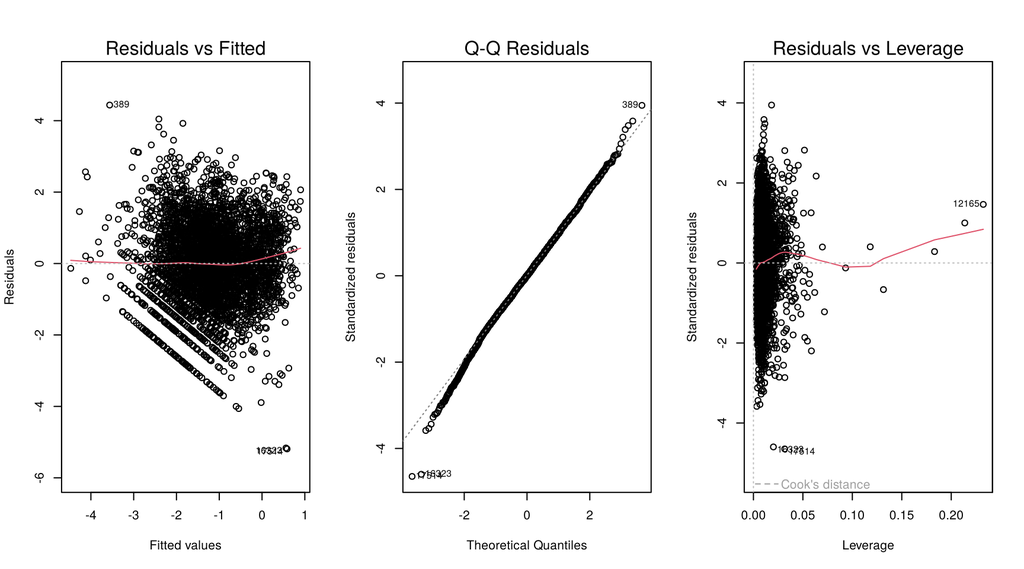

The residuals vs. fitted plot shows no strong curvature, and the spread of residuals is roughly constant across fitted values. The Q-Q plot indicates approximate normality of the residuals with some deviation in the tails, which is acceptable given the large sample size. No observation has a Cook’s distance close to 1.

**Low-sales pattern.** At the lowest fitted values, the residuals form straight diagonal bands rather than a random cloud. This comes from how VGChartz records sales: figures are rounded to 0.01 million units, so many low-selling games share exactly the same sales value (89 titles sit at the 0.01 million floor alone). When many observations share one value of Y but have different fitted values, their residuals fall on a line with slope −1. This is a data-recording artifact rather than evidence of a misspecified model, but it means the model’s errors are less well-behaved for the lowest-selling titles.

### Sensitivity Check: Excluding Very Low Sellers

To check whether those low-popularity observations drive our conclusions, we refit the final model without titles that sold 20,000 units or fewer (total_sales ≤ 0.02).

| Sample | Observations | Critic score (X360) | Adj_R2 |
| --- | --- | --- | --- |
| All titles | 3978 | 0.477 | 0.332 |
| Excluding sales <= 0.02M | 3800 | 0.477 | 0.309 |

Removing the 178 lowest sellers leaves the critic score coefficient essentially unchanged, with the same sign and significance. Our substantive conclusions are not driven by the low-sales observations.

### Multicollinearity Check

```
##                  GVIF Df GVIF^(1/(2*Df))
## critic_score 1.089813  1        1.043941
## genre_grp    1.421376 13        1.013616
## console_grp  1.447007 13        1.014313
```

We check multicollinearity on the additive Model 3, because interaction terms are correlated with their component variables by construction and would inflate VIFs mechanically. Critic score’s VIF is close to 1, and the adjusted generalized VIFs (GVIF^(1/(2·Df))) for genre and console are also close to 1, so multicollinearity is not a concern among the explanatory variables.

## Interpretations and Key Findings

The final model explains approximately **33.8%** of the variation in log(Global Sales) (adjusted R² = 0.332). Because the response is log(sales), each coefficient *b* translates into a multiplicative effect on sales: sales are multiplied by e^b, which is a percentage change of (e^b − 1) × 100%.

**Critic Score.** Because of the interaction, the effect of critic score differs by console. For the Xbox 360 reference group, the coefficient is 0.477. A one-point increase in critic score (on its 1 to 10 scale) multiplies expected global sales by e^0.477 ≈ **1.61**, that is, about **61% higher sales**, holding genre constant. The table below shows the same effect for every console group.

| Console | Critic score slope | Sales multiplier per +1 point | Change in sales |
| --- | --- | --- | --- |
| PS2 | 0.539 | 1.71 | 71% |
| PS4 | 0.489 | 1.63 | 63% |
| X360 | 0.477 | 1.61 | 61% |
| PS3 | 0.453 | 1.57 | 57% |
| XB | 0.448 | 1.56 | 56% |
| PC | 0.374 | 1.45 | 45% |
| PS | 0.361 | 1.44 | 44% |
| GC | 0.318 | 1.37 | 37% |
| PSP | 0.305 | 1.36 | 36% |
| Wii | 0.245 | 1.28 | 28% |
| Other | 0.189 | 1.21 | 21% |
| 3DS | 0.166 | 1.18 | 18% |
| DS | 0.166 | 1.18 | 18% |
| GBA | 0.124 | 1.13 | 13% |

Critic score is associated with higher sales on every console group, but the size of the payoff varies across platforms. The pattern is clear: reviews matter most on Sony and Microsoft home consoles (PS2, PS4, Xbox 360, PS3, Xbox) and least on Nintendo handhelds (GBA, DS, 3DS) and the Wii. One plausible explanation is that buyers on those Nintendo platforms rely more on first-party franchises and word of mouth than on critic reviews, though the model cannot confirm the reason.

**Genre.** Genre is significant as a group after controlling for critic score and console (separate partial F-test above). Holding critic score and console constant, Puzzle titles sell about 47% less than Action titles, Strategy titles about 35% less, and Role-Playing titles about 27% less. Shooter titles sell about 16% more than Action titles. Most other genres are not significantly different from Action.

**Console.** Console is significant as a group after controlling for critic score and genre (separate partial F-test above). Because console now interacts with critic score, the console coefficients describe the difference in sales between platforms for a hypothetical game with a critic score of zero, which is outside the data, so we interpret console differences through the slope table and the boxplots in the appendix rather than through the raw console coefficients.

## Limitations

- **Sample.** Only titles with a critic score are included, so the sample over-represents prominent releases.
- **Physical sales.** VGChartz mainly tracks physical retail sales. Platforms where most sales are digital, notably PC, will appear to sell less than they really do, which likely explains part of PC’s low estimated sales.
- **Omitted variables.** Marketing budget, franchise status, publisher, and release year are not in the model. Some of what we attribute to console may reflect when those consoles were on the market.
- **Association, not causation.** The model shows that well-reviewed games sell more; it does not prove that raising a game’s review score would by itself raise its sales.

## Final Summary and Recommendations

Our analysis finds that critic score, genre, and console are useful and statistically significant predictors of global video game sales, and that the payoff from strong reviews depends on the platform. We offer the following recommendations to a studio executive:

**Invest in quality.** Each additional point of critic score is associated with roughly 61% higher sales on the reference console, holding genre constant. Taking more time to polish a game before release is associated with meaningfully higher commercial outcomes.

**Match quality investment to the platform.** The return on a higher review score is largest on Sony and Microsoft home consoles and smallest on Nintendo handhelds. Polishing budgets go furthest where the model shows the steepest critic score slope.

**Target high-demand genres.** Shooter titles outsell Action titles on average, while Puzzle, Strategy, and Role-Playing titles sell substantially less, holding critic score and console constant. Studios entering those genres should plan budgets around lower expected unit sales.

## Appendix

### Diagnostic Plots: Model 1

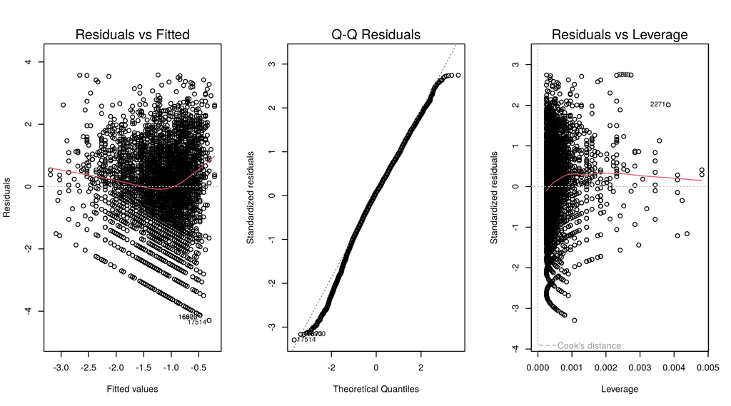

### Diagnostic Plots: Model 3

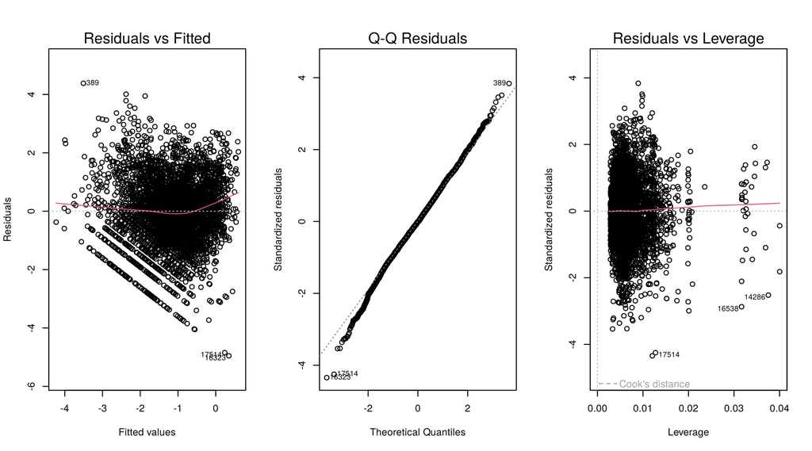

### Diagnostic Plots: Model 4

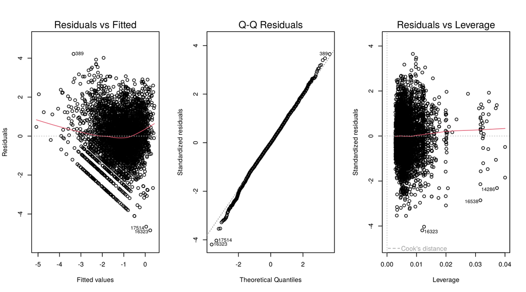

### log(Global Sales) by Genre

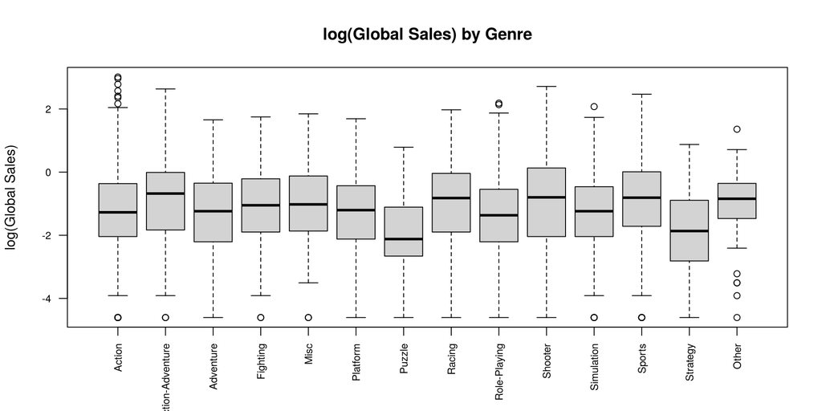

### log(Global Sales) by Console

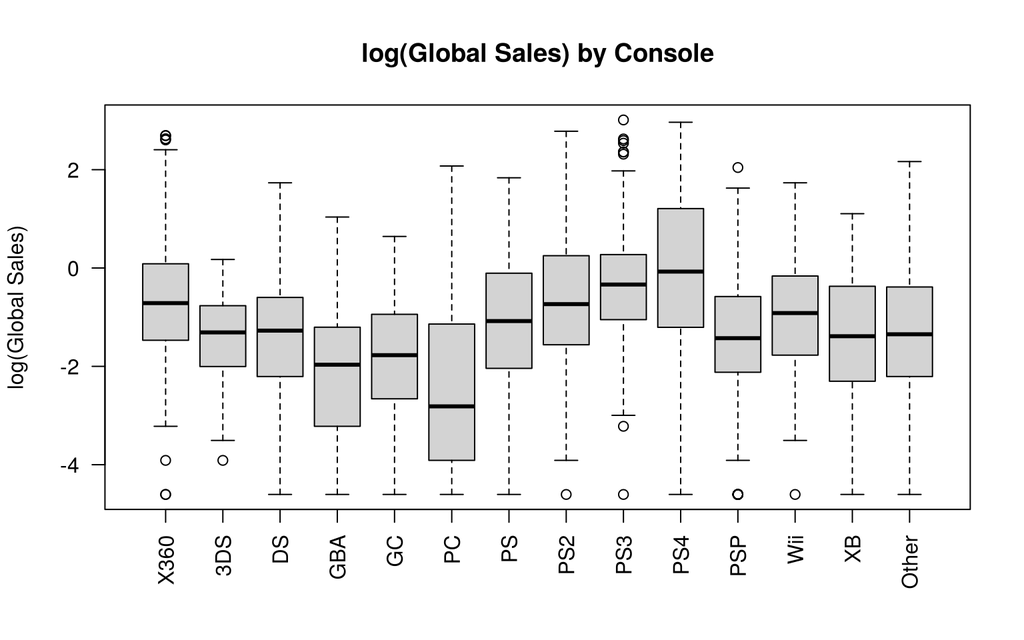

## References

- VGChartz. *Video Game Sales Data.* Retrieved via Kaggle: https://www.kaggle.com/datasets/asaniczka/video-game-sales-2024